# Tutorial 12: Advanced multi-level structures

Forschungspraktikum I und II: Vergleichende Sozialforschung mit Mehrebenenmodellen in R

Dr. Christian Czymara (Sociology with Focus on Quantitative Methods for Social Research, Goethe University Frankfurt)

In this tutorial, we will examine relationships on various levels, i.e. spatial units. While we have focused on clustering on the country level so far, we will now take a more fine-grained perspective. In particular, we will use the [Nomenclature des unités territoriales statistiques](https://en.wikipedia.org/wiki/Nomenclature_of_Territorial_Units_for_Statistics#Member_states), which are lower geographical regions. Let’s take Germany as an example: the German NUTS1 regions are the 16 states (*Bundesländer*, e. g.: Hesse), NUTS2 are 39 government regions (*Regierungbezirke*, e. g.: Darmstadt), NUTS3 are 429 districts (*Landkreise* and *kreisfreie Städte*, e. g.: Frankfurt am Main). We will look at the sixth wave of the ESS to analyze the relationship between economic wealth on these different levels and the variable `plinsoc`, which measures respondents perceived place in society (0: bottom, 10: top).

## 1. Data preparation

Import ESS6MDWe02.4_F1.dta and assign it to object `ESS6_NUTS123`.

```r
library("haven")

ESS6_NUTS123 <- read_dta("ESS6MDWe02.4_F1.dta")
```

```
## Invalid timestamp string (length=17): 15 jan. 2022 16
```

## 2. Understanding NUTS regions: Descriptive overview

To get a grasp of what these NUTS regions are, we will start with some exploratory data analyses.

### a) Examples of NUTS regions

We already know the variable that captures countries: `cntry`. The respective variables for the NUTS regions are called, surprise, `NUTS1`, `NUTS2`, and `NUTS3`. What are exemplary values for each of these variables?

```r
# what do these levels look like?
sample(ESS6_NUTS123$cntry, 5)
```

```
## [1] "RU" "GB" "IL" "XK" "SI"
```

```r
sample(ESS6_NUTS123$NUTS1, 5)
```

```
## [1] "SE2" "NL4" "FI1" "UKK" "DE7"
```

```r
sample(ESS6_NUTS123$NUTS2, 5)
```

```
## [1] "FR53" "IE01" "FI19" "BE25" "ES11"
```

```r
sample(ESS6_NUTS123$NUTS3, 5)
```

```
## [1] ""      ""      ""      "FI196" ""
```

### b) GDP values of different levels

We can measure economic prosperity (using GDP per capita) on each of these levels. This means we have one GDP variable per level in our dataset:

- Country: `c_gdp_eurhab_2011`
- NUTS1: `n1_gdp_eurhab_2011`
- NUTS2: `n2_gdp_eurhab_2011`
- NUTS3: `n3_gdp_eurhab_2011`

Unfortunately, it will turn out that we do not have the data for all regions, i.e. that there are many NA’s for some of these variables. How many observations are there for each of these four variables? How large are the percentages of missing values?

```r
# define GDP wars
GDPvars <- c("c_gdp_eurhab_2011",
             "n1_gdp_eurhab_2011",
             "n2_gdp_eurhab_2011",
             "n3_gdp_eurhab_2011")

# how many observations are there on each level?
sapply(ESS6_NUTS123[, GDPvars],  function(x) length(unique(x)))
```

```
##  c_gdp_eurhab_2011 n1_gdp_eurhab_2011 n2_gdp_eurhab_2011 n3_gdp_eurhab_2011
##                 25                 78                132                116
```

```r
# for how many cases is data available on each level?
sapply(ESS6_NUTS123[, GDPvars],  function(x) prop.table(table(is.na(x))))
```

```
##       c_gdp_eurhab_2011 n1_gdp_eurhab_2011 n2_gdp_eurhab_2011
## FALSE         0.8232034          0.7821411          0.6658131
## TRUE          0.1767966          0.2178589          0.3341869
##       n3_gdp_eurhab_2011
## FALSE          0.3758345
## TRUE           0.6241655
```

Show some descriptive statistics for each variable (mean values etc.).

```r
# summary statistics per level
sapply(ESS6_NUTS123[, GDPvars], summary)
```

```
##         c_gdp_eurhab_2011 n1_gdp_eurhab_2011 n2_gdp_eurhab_2011
## Min.              5200.00            3900.00            3200.00
## 1st Qu.          12800.00           12800.00           12100.00
## Median           28200.00           22800.00           22300.00
## Mean             26583.06           24290.98           23708.06
## 3rd Qu.          35000.00           35100.00           34800.00
## Max.             71300.00           62000.00           72600.00
## NA's              9666.00           11911.00           18271.00
##         n3_gdp_eurhab_2011
## Min.               2600.00
## 1st Qu.            8100.00
## Median            13900.00
## Mean              19339.94
## 3rd Qu.           29100.00
## Max.              56200.00
## NA's              34125.00
```

```r
# in addition: outcome
mean(ESS6_NUTS123$plinsoc, na.rm = T)
```

```
## [1] 5.443948
```

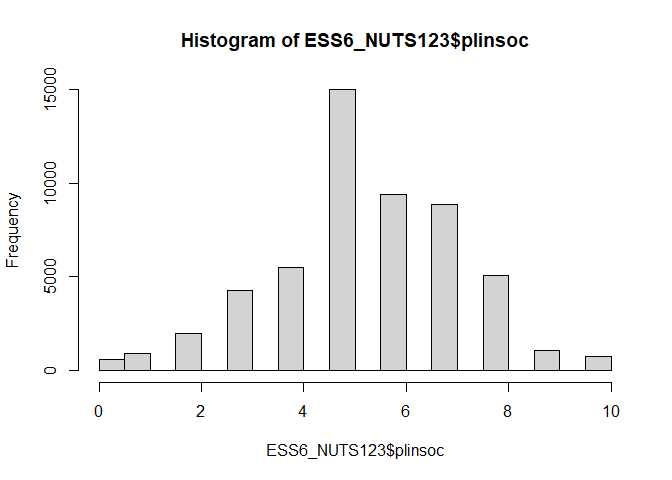

```r
hist(ESS6_NUTS123$plinsoc)
```

### c) Example: Uppsala län (Sweden)

Let’s have a look at an example on the NUTS3 level. The NUTS3 level in Sweden consists of [counties (called *läns*)](https://en.wikipedia.org/wiki/Counties_of_Sweden). An example of a län is the *Uppsala län*, which is [value `SE121` of `NUTS3`](http://www.europeansocialsurvey.org/essdoc/doc.html?ddi=2.2.3.5&year=2012&land=752). How many respondents are in the sample for Uppsala län?

```r
table(ESS6_NUTS123$NUTS3 == "SE121")
```

```
##
## FALSE  TRUE
## 54626    47
```

How large was the GDP of Uppsala län in 2011? Is it above or below Sweden’s overall GDP value?

```r
ESS6_NUTS123[ESS6_NUTS123$NUTS3 == "SE121", ]$n3_gdp_eurhab_2011[1]
```

```
## [1] 36100
```

```r
ESS6_NUTS123[ESS6_NUTS123$NUTS3 == "SE121", ]$n3_gdp_eurhab_2011[1] > ESS6_NUTS123[ESS6_NUTS123$cntry == "SE", ]$c_gdp_eurhab_2011[1] # below
```

```
## [1] FALSE
```

### d) GDP and perceived place in society

Plot the bivariate associations between `plinsoc` and the four GDP variables (one plot per region). Note that the small size of the regional samples (especially NUTS3) does not ensure regional representativity.

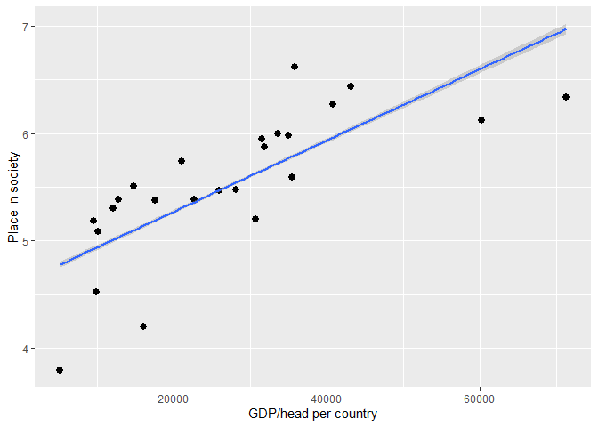

```r
library(tidyverse)

# country
ESS6_NUTS123 %>%
  ggplot(aes(x = c_gdp_eurhab_2011,
             y = plinsoc)) +
  stat_summary(fun = mean) +
  geom_smooth(method = "lm") +
  ylab("Place in society") +
  xlab("GDP/head per country")
```

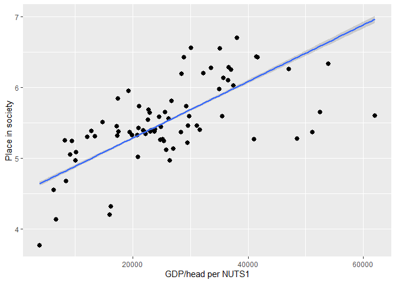

```r
# NUTS1
ESS6_NUTS123 %>%
  ggplot(aes(x = n1_gdp_eurhab_2011,
             y = plinsoc)) +
  stat_summary(fun = mean) +
  geom_smooth(method = "lm") +
  ylab("Place in society") +
  xlab("GDP/head per NUTS1")
```

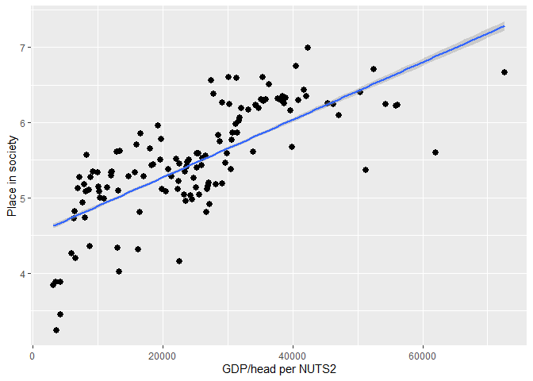

```r
# NUTS2
ESS6_NUTS123 %>%
  ggplot(aes(x = n2_gdp_eurhab_2011,
             y = plinsoc)) +
  stat_summary(fun = mean) +
  geom_smooth(method = "lm") +
  ylab("Place in society") +
  xlab("GDP/head per NUTS2")
```

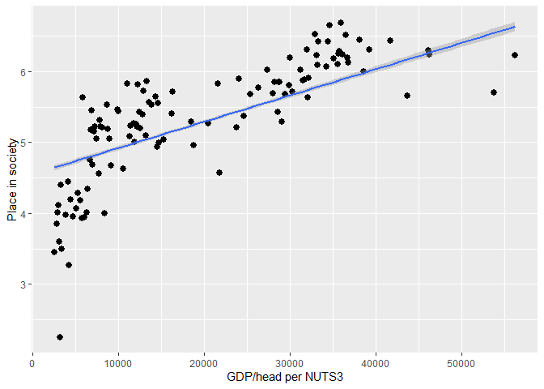

```r
# NUTS 3
ESS6_NUTS123 %>%
  ggplot(aes(x = n3_gdp_eurhab_2011,
             y = plinsoc)) +
  stat_summary(fun = mean) +
  geom_smooth(method = "lm") +
  ylab("Place in society") +
  xlab("GDP/head per NUTS3")
```

## 3. Random intercept(s) models

Now we are ready to run some multi-level models. Compared to the last sessions, these models will have random intercepts on several levels: individuals (level 1) are nested in NUTS2 regions (level 2), NUTS2 regions are nested in NUTS1 regions (level 3), and NUTS1 regions are nested in countries (level 4). We skip the NUTS3 level because the five level model will not converge and due to the representativity issues raised above.

### a) Null model

To understand the correct random effects structure, we start with the null model. Use `lmer()` to estimate a null model that has the following random effects structure, where $plinsoc_{ijkl}$ is the perceived place in society of individual $i$ living in NUTS2 region $j$ within NUTS1 region $k$ of country $l$. $u_{0l}$ is the random intercept on the country-level (between countries), $u_{0kl}$ the random intercept on the NUTS1 level (within countries), , $u_{0jkl}$ the random intercept on the NUTS2 level (within NUTS1), and $e_{ijkl}$ is the individual level error term (within NUTS2):

$$plinsoc_{ijkl}=\beta_{0}+u_{0l}+u_{0kl}+u_{0jkl}+e_{ijkl}$$

Then calculate the ICC to obtain the share of variance of `plinsoc` on each level (either manually or use the `performance` package).

```r
# models
library(lme4)

# five level null model (not working)
# m0 <- lmer(plinsoc ~ 1 + (1 | cntry/NUTS1/NUTS2/NUTS3),
#              data = ESS6_NUTS123)

# four level null model
m0 <- lmer(plinsoc ~ 1 + (1 | cntry/NUTS1/NUTS2),
              data = ESS6_NUTS123)


summary(m0, correlation = F)
```

```
## Linear mixed model fit by REML ['lmerMod']
## Formula: plinsoc ~ 1 + (1 | cntry/NUTS1/NUTS2)
##    Data: ESS6_NUTS123
##
## REML criterion at convergence: 208875.7
##
## Scaled residuals:
##     Min      1Q  Median      3Q     Max
## -3.8797 -0.6391 -0.0292  0.6388  3.9284
##
## Random effects:
##  Groups              Name        Variance Std.Dev.
##  NUTS2:(NUTS1:cntry) (Intercept) 0.04302  0.2074
##  NUTS1:cntry         (Intercept) 0.01251  0.1119
##  cntry               (Intercept) 0.50892  0.7134
##  Residual                        2.89666  1.7020
## Number of obs: 53441, groups:
## NUTS2:(NUTS1:cntry), 200; NUTS1:cntry, 88; cntry, 29
##
## Fixed effects:
##             Estimate Std. Error t value
## (Intercept)   5.4949     0.1361   40.37
```

```r
library(performance)
performance::icc(m0, by_group = T)
```

```
## # ICC by Group
##
## Group               |   ICC
## ---------------------------
## NUTS2:(NUTS1:cntry) | 0.012
## NUTS1:cntry         | 0.004
## cntry               | 0.147
```

### b) Add GDP variables

In a next step, we add the three GDP variables (on the country, NUTS1, and NUTS2 levels). First, run three models, each containing only one of these variables. Then run a a model that includes all three variables simultaneously. Compare the results. Note that the sample of analysis differs quite substantively between some of these models (compare N), so comparisons should be seen with caution.

```r
# four level model with country predictors
m1_gdp_c <- lmer(plinsoc ~ c_gdp_eurhab_2011 +  (1 | cntry/NUTS1/NUTS2),
              data = ESS6_NUTS123)
m1_gdp_n1 <- lmer(plinsoc ~ n1_gdp_eurhab_2011 + (1 | cntry/NUTS1/NUTS2),
              data = ESS6_NUTS123)
m1_gdp_n2 <- lmer(plinsoc ~ n2_gdp_eurhab_2011 + (1 | cntry/NUTS1/NUTS2),
              data = ESS6_NUTS123)

# all in one model
m1_gdp_all <- lmer(plinsoc ~ c_gdp_eurhab_2011 + n1_gdp_eurhab_2011 + n2_gdp_eurhab_2011 + (1 | cntry/NUTS1/NUTS2),
              data = ESS6_NUTS123)

library(sjPlot)

tab_model(m1_gdp_c, m1_gdp_n1, m1_gdp_n2, m1_gdp_all,
          show.std = T,
          show.est = F)
```

|  | Your place in society |  |  | Your place in society |  |  | Your place in society |  |  | Your place in society |  |  |
| --- | --- | --- | --- | --- | --- | --- | --- | --- | --- | --- | --- | --- |
| Predictors | std. Beta | standardized CI | p | std. Beta | standardized CI | p | std. Beta | standardized CI | p | std. Beta | standardized CI | p |
| (Intercept) | 0.00 | -0.10 – 0.11 | **<0.001** | 0.01 | -0.13 – 0.15 | **<0.001** | 0.01 | -0.13 – 0.16 | **<0.001** | 0.00 | -0.12 – 0.13 | **<0.001** |
| [COUNTRY]GDP at current market prices-Euro per inhabitant 2011 | 0.27 | 0.17 – 0.37 | **<0.001** |  |  |  |  |  |  | 0.29 | 0.15 – 0.43 | **<0.001** |
| [NUTS 1]GDP at current market prices-Euro per inhabitant 2011 |  |  |  | 0.06 | 0.01 – 0.12 | **0.028** |  |  |  | -0.13 | -0.22 – -0.03 | **0.008** |
| [NUTS 2]GDP at current market prices-Euro per inhabitant 2011 |  |  |  |  |  |  | 0.12 | 0.07 – 0.16 | **<0.001** | 0.14 | 0.08 – 0.20 | **<0.001** |
| Random Effects |  |  |  |  |  |  |  |  |  |  |  |  |
| σ<sup>2</sup> | 2.76 |  |  | 2.77 |  |  | 2.78 |  |  | 2.78 |  |  |
| τ<sub>00</sub> | 0.04 <sub>NUTS2:(NUTS1:cntry)</sub> |  |  | 0.04 <sub>NUTS2:(NUTS1:cntry)</sub> |  |  | 0.03 <sub>NUTS2:(NUTS1:cntry)</sub> |  |  | 0.03 <sub>NUTS2:(NUTS1:cntry)</sub> |  |  |
|  | 0.01 <sub>NUTS1:cntry</sub> |  |  | 0.01 <sub>NUTS1:cntry</sub> |  |  | 0.02 <sub>NUTS1:cntry</sub> |  |  | 0.02 <sub>NUTS1:cntry</sub> |  |  |
|  | 0.19 <sub>cntry</sub> |  |  | 0.35 <sub>cntry</sub> |  |  | 0.33 <sub>cntry</sub> |  |  | 0.22 <sub>cntry</sub> |  |  |
| ICC | 0.08 |  |  | 0.13 |  |  | 0.12 |  |  | 0.09 |  |  |
| N | 167 <sub>NUTS2</sub> |  |  | 159 <sub>NUTS2</sub> |  |  | 158 <sub>NUTS2</sub> |  |  | 158 <sub>NUTS2</sub> |  |  |
|  | 83 <sub>NUTS1</sub> |  |  | 81 <sub>NUTS1</sub> |  |  | 52 <sub>NUTS1</sub> |  |  | 52 <sub>NUTS1</sub> |  |  |
|  | 24 <sub>cntry</sub> |  |  | 22 <sub>cntry</sub> |  |  | 19 <sub>cntry</sub> |  |  | 19 <sub>cntry</sub> |  |  |
| Observations | 44133 |  |  | 41966 |  |  | 35715 |  |  | 35715 |  |  |
| Marginal R<sup>2</sup> / Conditional R<sup>2</sup> | 0.072 / 0.149 |  |  | 0.004 / 0.130 |  |  | 0.014 / 0.133 |  |  | 0.089 / 0.170 |  |  |

### c) Add individual-level controls

Use the model that includes all three variables and add the individual-level variables income satisfaction (`hincfel`, categorical), education (`eduyrs`, measured in years), and gender (`gndr`).

```r
m2_ind <- lmer(plinsoc ~ c_gdp_eurhab_2011 + n1_gdp_eurhab_2011 + n2_gdp_eurhab_2011 +
                        factor(hincfel) + eduyrs + gndr + (1 | cntry/NUTS1/NUTS2),
              data = ESS6_NUTS123)

tab_model(m2_ind,
          show.std = T,
          show.est = F)
```

|  | Your place in society |  |  |
| --- | --- | --- | --- |
| Predictors | std. Beta | standardized CI | p |
| (Intercept) | 0.41 | 0.32 – 0.49 | **<0.001** |
| [COUNTRY]GDP at current market prices-Euro per inhabitant 2011 | 0.17 | 0.07 – 0.28 | **0.001** |
| [NUTS 1]GDP at current market prices-Euro per inhabitant 2011 | -0.10 | -0.19 – -0.02 | **0.015** |
| [NUTS 2]GDP at current market prices-Euro per inhabitant 2011 | 0.08 | 0.03 – 0.14 | **0.002** |
| factor(hincfel)2 | -0.32 | -0.34 – -0.29 | **<0.001** |
| factor(hincfel)3 | -0.68 | -0.71 – -0.65 | **<0.001** |
| factor(hincfel)4 | -1.21 | -1.24 – -1.17 | **<0.001** |
| Years of full-time education completed | 0.15 | 0.14 – 0.16 | **<0.001** |
| Gender | -0.00 | -0.01 – 0.01 | 0.426 |
| Random Effects |  |  |  |
| σ<sup>2</sup> | 2.32 |  |  |
| τ<sub>00</sub> <sub>NUTS2:(NUTS1:cntry)</sub> | 0.03 |  |  |
| τ<sub>00</sub> <sub>NUTS1:cntry</sub> | 0.01 |  |  |
| τ<sub>00</sub> <sub>cntry</sub> | 0.09 |  |  |
| ICC | 0.05 |  |  |
| N <sub>NUTS2</sub> | 158 |  |  |
| N <sub>NUTS1</sub> | 52 |  |  |
| N <sub>cntry</sub> | 19 |  |  |
| Observations | 35141 |  |  |
| Marginal R<sup>2</sup> / Conditional R<sup>2</sup> | 0.249 / 0.289 |  |  |

## 4. Random slope of education

Finally, let’s test whether the relationship between years of education and perceived place in society differs across contexts. As we now have four levels, we could let the individual-level education effect vary on each of the three higher levels.

### a) Between countries

Model a random slope of `eduyrs` between *countries* (other variables not shown in equation for simplicity):

$$plinsoc_{ijkl}=\beta_0+\beta_1eduyrs_{ijkl}+u_{0l}+\boldsymbol{u_{1l}}*eduyrs_{ijkl}+u_{0kl}+u_{0jkl}+e_{ijkl}$$

```r
m3_RS_c <- lmer(plinsoc ~ c_gdp_eurhab_2011 + n1_gdp_eurhab_2011 + n2_gdp_eurhab_2011 +
                        factor(hincfel) + eduyrs + gndr + (1 + eduyrs | cntry) + (1 | cntry:NUTS1) + (1 | cntry:NUTS1:NUTS2),
              data = ESS6_NUTS123)
```

### b) Between NUTS1 regions

Model a random slope of `eduyrs` between *NUTS1* regions (within countries):

$$plinsoc_{ijkl}=\beta_0+\beta_1eduyrs_{ijkl}+u_{0l}+u_{0kl}+\boldsymbol{u_{1kl}}*eduyrs_{ijkl}+u_{0jkl}+e_{ijkl}$$

Compare to the results of 4.a).

```r
# random slope for education between NUTS1 (within countries)
m3_RS_n1 <- lmer(plinsoc ~ c_gdp_eurhab_2011 + n1_gdp_eurhab_2011 + n2_gdp_eurhab_2011 +
                        factor(hincfel) + eduyrs + gndr + (1 | cntry) + (1 + eduyrs| cntry:NUTS1) + (1 | cntry:NUTS1:NUTS2),
              data = ESS6_NUTS123)

tab_model(m3_RS_c, m3_RS_n1,
          show.std = T,
          show.est = F)
```

|  | Your place in society |  |  |  | Your place in society |  |  |  |
| --- | --- | --- | --- | --- | --- | --- | --- | --- |
| Predictors | std. Beta | standardized CI | p | std. p | std. Beta | standardized CI | p | std. p |
| (Intercept) | 0.41 | 0.33 – 0.49 | **<0.001** | **<0.001** | 0.41 | 0.33 – 0.49 | **<0.001** | **<0.001** |
| [COUNTRY]GDP at current market prices-Euro per inhabitant 2011 | 0.17 | 0.07 – 0.27 | **0.001** | **0.001** | 0.16 | 0.07 – 0.26 | **0.001** | **0.001** |
| [NUTS 1]GDP at current market prices-Euro per inhabitant 2011 | -0.09 | -0.17 – -0.01 | **0.030** | **0.029** | -0.09 | -0.17 – -0.01 | **0.025** | **0.025** |
| [NUTS 2]GDP at current market prices-Euro per inhabitant 2011 | 0.08 | 0.03 – 0.13 | **0.003** | **0.003** | 0.08 | 0.03 – 0.13 | **0.002** | **0.002** |
| factor(hincfel)2 | -0.33 | -0.35 – -0.30 | **<0.001** | **<0.001** | -0.33 | -0.35 – -0.30 | **<0.001** | **<0.001** |
| factor(hincfel)3 | -0.68 | -0.71 – -0.65 | **<0.001** | **<0.001** | -0.68 | -0.71 – -0.65 | **<0.001** | **<0.001** |
| factor(hincfel)4 | -1.17 | -1.21 – -1.14 | **<0.001** | **<0.001** | -1.18 | -1.21 – -1.14 | **<0.001** | **<0.001** |
| Years of full-time education completed | 0.17 | 0.13 – 0.21 | **<0.001** | **<0.001** | 0.15 | 0.12 – 0.17 | **<0.001** | **<0.001** |
| Gender | -0.00 | -0.01 – 0.01 | 0.435 | 0.435 | -0.00 | -0.01 – 0.01 | 0.444 | 0.444 |
| Random Effects |  |  |  |  |  |  |  |  |
| σ<sup>2</sup> | 2.30 |  |  |  | 2.30 |  |  |  |
| τ<sub>00</sub> | 0.02 <sub>cntry:NUTS1:NUTS2</sub> |  |  |  | 0.02 <sub>cntry:NUTS1:NUTS2</sub> |  |  |  |
|  | 0.01 <sub>cntry:NUTS1</sub> |  |  |  | 0.28 <sub>cntry:NUTS1</sub> |  |  |  |
|  | 0.31 <sub>cntry</sub> |  |  |  | 0.08 <sub>cntry</sub> |  |  |  |
| τ<sub>11</sub> | 0.00 <sub>cntry.eduyrs</sub> |  |  |  | 0.00 <sub>cntry:NUTS1.eduyrs</sub> |  |  |  |
| ρ<sub>01</sub> | -0.86 <sub>cntry</sub> |  |  |  | -0.98 <sub>cntry:NUTS1</sub> |  |  |  |
| ICC | 0.06 |  |  |  | 0.06 |  |  |  |
| N | 19 <sub>cntry</sub> |  |  |  | 19 <sub>cntry</sub> |  |  |  |
|  | 52 <sub>NUTS1</sub> |  |  |  | 52 <sub>NUTS1</sub> |  |  |  |
|  | 158 <sub>NUTS2</sub> |  |  |  | 158 <sub>NUTS2</sub> |  |  |  |
| Observations | 35141 |  |  |  | 35141 |  |  |  |
| Marginal R<sup>2</sup> / Conditional R<sup>2</sup> | 0.255 / 0.300 |  |  |  | 0.241 / 0.287 |  |  |  |

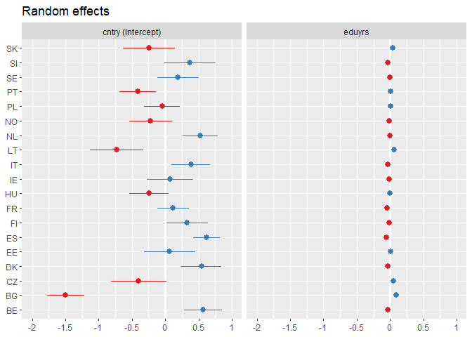

```r
plot_model(m3_RS_c, type = "re")[[3]] # random slope on country level
```

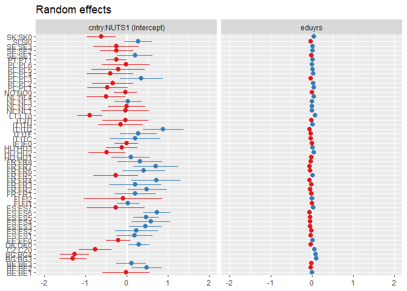

```r
plot_model(m3_RS_n1, type = "re")[[2]] # random slope on NUTS1 level
```